# Analisis Insight Coffee Chain Dataset

Finalia Salwa | M0725065

2026-04-17

```r
# Memuat paket yang diperlukan untuk koneksi database dan visualisasi
library(DBI)
library(ggplot2)
library(dplyr)
library(odbc)
```

# I. Pendahuluan

Dalam era perkembangan teknologi informasi, data menjadi salah satu aset penting dalam mendukung pengambilan keputusan yang tepat dan efektif. Perusahaan dituntut untuk mampu mengolah dan menganalisis data secara optimal guna memahami kondisi bisnis serta mengidentifikasi peluang yang dapat meningkatkan kinerja perusahaan.

Salah satu pendekatan yang dapat digunakan adalah analisis data menggunakan metode statistika dan visualisasi data. Melalui visualisasi, pola dan hubungan antar variabel dapat terlihat dengan lebih jelas, sedangkan metode statistika digunakan untuk menguji signifikansi dari hubungan tersebut secara lebih objektif.

Dataset Coffee Chain digunakan dalam analisis ini untuk mengeksplorasi hubungan antara variabel penjualan (Sales), keuntungan (Profit), serta performa berdasarkan produk dan market. Analisis dilakukan dengan menggabungkan data dari beberapa tabel menggunakan query SQL, sehingga informasi yang diperoleh menjadi lebih lengkap dan komprehensif.

Dengan dilakukan analisis ini, diharapkan dapat diperoleh insight yang dapat membantu perusahaan dalam memahami faktor-faktor yang mempengaruhi profit serta mendukung pengambilan keputusan bisnis yang lebih tepat.

# II. Tujuan analisis

1. Mengetahui hubungan antara Sales dan Profit
2. Mengidentifikasi produk dengan profit tertinggi
3. Mengetahui market yang paling menguntungkan
4. Mengetahui perbedaan profit berdasarkan market

# III. Koneksi dan Pengambilan Data

```r
con = dbConnect(odbc(),
          Driver = "MySQL ODBC 8.0 ANSI Driver",
          Server = "127.0.0.1",
          UID = "root",
          PWD = "Finalia1737",
          Port = 3306,
          Database = "coffechain")

query = " SELECT f.Sales, f.Profit, p.Product, l.Market
FROM facttable f
JOIN product p ON f.productId = p.productId
JOIN location l ON f.`Area Code` = l.`Area Code` "

data <- dbGetQuery(con, query)
head(data)
```

```
##   Sales Profit           Product  Market
## 1   219     94          Amaretto Central
## 2   190     68         Colombian Central
## 3   234    101 Decaf Irish Cream Central
## 4   100     30         Green Tea Central
## 5   134     54       Caffe Mocha Central
## 6   180     53    Decaf Espresso Central
```

# IV. Deskirpsi Insight

Dalam analisis ini, beberapa insight utama dipilih untuk menggambarkan kondisi kinerja bisnis pada Coffee Chain Dataset secara komprehensif. Insight yang diambil difokuskan pada hubungan antara variabel utama serta perbandingan performa antar kategori.

- Insight pertama adalah hubungan antara Sales dan Profit. Analisis ini bertujuan untuk mengetahui apakah peningkatan penjualan secara langsung berdampak pada peningkatan keuntungan perusahaan. Hubungan ini penting untuk memahami efektivitas strategi penjualan yang diterapkan serta sejauh mana penjualan mampu menghasilkan profit.
- Insight kedua adalah analisis profit berdasarkan produk. Setiap produk memiliki karakteristik yang berbeda, baik dari segi harga, biaya produksi, maupun tingkat permintaan pasar. Oleh karena itu, penting untuk mengidentifikasi produk mana yang memberikan kontribusi terbesar terhadap total profit perusahaan. Informasi ini dapat digunakan untuk menentukan produk unggulan serta strategi pengembangan produk ke depan.
- Insight ketiga adalah analisis profit berdasarkan market. Setiap market atau wilayah memiliki kondisi yang berbeda, seperti daya beli konsumen, tingkat persaingan, dan preferensi pelanggan. Analisis ini bertujuan untuk mengetahui market mana yang paling menguntungkan dan memiliki potensi terbesar untuk dikembangkan. Dengan demikian, perusahaan dapat mengalokasikan sumber daya secara lebih efektif.

Ketiga insight tersebut dipilih karena saling berkaitan dan memberikan gambaran menyeluruh mengenai faktor-faktor yang mempengaruhi profit perusahaan. Dengan menggabungkan analisis hubungan variabel, perbandingan kategori produk, dan segmentasi market, diharapkan diperoleh pemahaman yang lebih mendalam dalam mendukung pengambilan keputusan bisnis.

# V. Analisis Insight

## 5.1. Analisis 1: Hubungan Sales dan Profit

### 5.1.1. Visualisasi

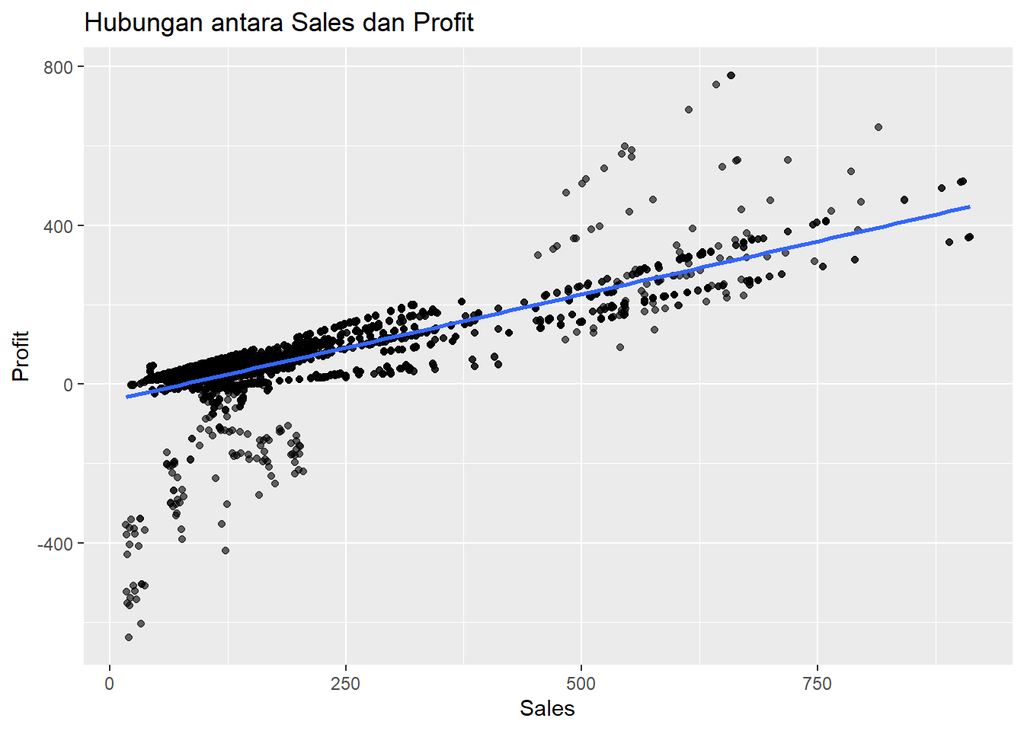

```r
ggplot(data, aes(x = Sales, y = Profit)) +
  geom_point(alpha = 0.6) +
  geom_smooth(method = "lm", se = FALSE) +
  labs(title = "Hubungan antara Sales dan Profit")
```

```r
cor(data$Sales, data$Profit)
```

```
## [1] 0.7973309
```

### 5.1.2 Analisis Statistika

```r
cor.test(data$Sales, data$Profit)
```

```
##
##  Pearson's product-moment correlation
##
## data:  data$Sales and data$Profit
## t = 86.084, df = 4246, p-value < 2.2e-16
## alternative hypothesis: true correlation is not equal to 0
## 95 percent confidence interval:
##  0.7861073 0.8080289
## sample estimates:
##       cor
## 0.7973309
```

### 5.1.3 Interpretasi

Berdasarkan hasil visualisasi scatter plot, terlihat adanya pola hubungan positif antara variabel Sales dan Profit. Hal ini menunjukkan bahwa secara umum peningkatan nilai penjualan diikuti oleh peningkatan keuntungan yang diperoleh perusahaan.

Garis regresi linear yang ditampilkan pada grafik memperkuat indikasi adanya hubungan linear antara kedua variabel tersebut. Namun, penyebaran titik data yang cukup bervariasi di sekitar garis regresi menunjukkan bahwa hubungan ini tidak bersifat sempurna.

Hasil uji korelasi Pearson memberikan nilai koefisien korelasi (r) yang menunjukkan kekuatan hubungan antara Sales dan Profit. Selain itu, nilai p-value digunakan untuk menguji signifikansi hubungan tersebut. Jika p-value < 0.05, maka dapat disimpulkan bahwa hubungan antara kedua variabel signifikan secara statistik.

Dengan demikian, dapat disimpulkan bahwa Sales merupakan faktor penting yang mempengaruhi Profit, meskipun masih terdapat faktor lain yang turut berkontribusi, seperti biaya operasional, strategi harga, dan efisiensi distribusi.

## 5.2 Analisis 2: Profit Berdasarkan Produk

### 5.2.1 Visualisasi

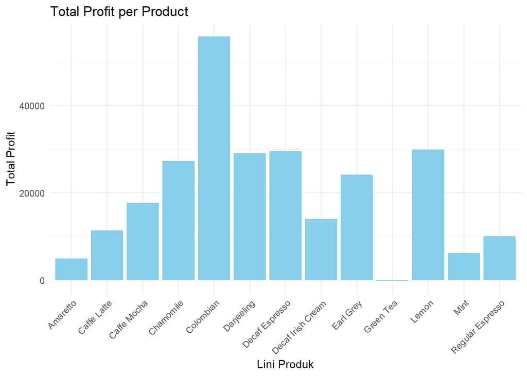

```r
product_profit <- data %>%
  group_by(Product) %>%
  summarise(Total_Profit = sum(Profit))

ggplot(product_profit, aes(x = Product, y = Total_Profit)) +
  geom_bar(stat = "identity", fill="skyblue") +
  theme_minimal()+
  labs(title = "Total Profit per Product",
       x = "Lini Produk",
       y = "Total Profit") +
  theme(axis.text.x = element_text(angle = 45, hjust = 1))
```

### 5.2.2 Analisis Statistika

```r
anova_product <- aov(Profit ~ Product, data = data)
summary(anova_product)
```

```
##               Df   Sum Sq Mean Sq F value Pr(>F)
## Product       12  4267412  355618   37.97 <2e-16 ***
## Residuals   4235 39666224    9366
## ---
## Signif. codes:  0 '***' 0.001 '**' 0.01 '*' 0.05 '.' 0.1 ' ' 1
```

### 5.2.3 Intepretasi

Visualisasi total profit berdasarkan produk menunjukkan adanya variasi yang cukup signifikan antar produk. Beberapa produk memiliki total profit yang jauh lebih tinggi dibandingkan produk lainnya, yang mengindikasikan bahwa produk tersebut memiliki performa yang lebih baik dalam menghasilkan keuntungan.

Perbedaan ini dapat disebabkan oleh beberapa faktor, seperti tingkat permintaan pasar, harga jual, biaya produksi, serta strategi pemasaran yang diterapkan pada masing-masing produk.

Hasil uji ANOVA digunakan untuk menguji apakah perbedaan rata-rata profit antar produk tersebut signifikan secara statistik. Jika nilai p-value < 0.05, maka dapat disimpulkan bahwa terdapat perbedaan yang signifikan antara minimal satu kelompok produk dengan kelompok lainnya.

Dengan demikian, jenis produk terbukti memiliki pengaruh terhadap profit yang dihasilkan. Informasi ini dapat digunakan oleh perusahaan untuk menentukan produk unggulan yang perlu diprioritaskan dalam strategi bisnis, serta mengevaluasi produk dengan performa rendah.

## 5.3 Analisis 3: Profit Berdasarkan Market

### 5.3.1 Visualisasi

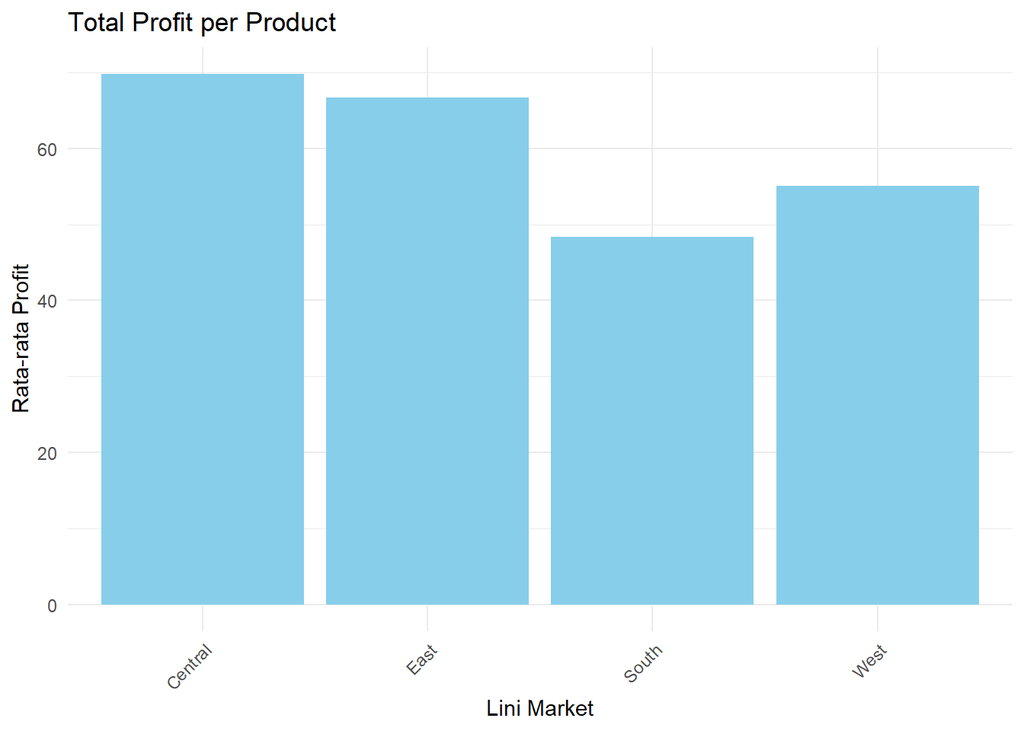

```r
market_profit <- data %>%
                 group_by(Market) %>%
                 summarise(Avg_Profit = mean(Profit))

ggplot(market_profit, aes(x = Market, y = Avg_Profit)) +
  geom_bar(stat = "identity", fill="skyblue") +
  theme_minimal()+
  labs(title = "Total Profit per Product",
       x = "Lini Market",
       y = "Rata-rata Profit") +
  theme(axis.text.x = element_text(angle = 45, hjust = 1))
```

### 5.3.2 Analisis Statistika

```r
anova_market <- aov(Profit ~ Market, data = data)
summary(anova_market)
```

```
##               Df   Sum Sq Mean Sq F value   Pr(>F)
## Market         3   288811   96270   9.361 3.64e-06 ***
## Residuals   4244 43644825   10284
## ---
## Signif. codes:  0 '***' 0.001 '**' 0.01 '*' 0.05 '.' 0.1 ' ' 1
```

### 5.3.3 Intepretasi

Berdasarkan visualisasi rata-rata profit per market, terlihat bahwa terdapat perbedaan performa profit antar wilayah pasar. Hal ini menunjukkan bahwa kondisi pasar di setiap wilayah memiliki karakteristik yang berbeda dalam menghasilkan keuntungan.

Perbedaan tersebut dapat dipengaruhi oleh berbagai faktor, seperti tingkat daya beli konsumen, intensitas persaingan, preferensi pelanggan, serta efektivitas distribusi di masing-masing wilayah.

Hasil uji ANOVA digunakan untuk menguji apakah perbedaan rata-rata profit antar market tersebut signifikan secara statistik. Jika nilai p-value < 0.05, maka dapat disimpulkan bahwa perbedaan tersebut tidak terjadi secara kebetulan, melainkan memang dipengaruhi oleh faktor market.

Dengan demikian, market memiliki peran penting dalam menentukan tingkat profit perusahaan. Perusahaan dapat memanfaatkan informasi ini untuk mengalokasikan sumber daya secara lebih optimal, dengan memfokuskan strategi pada market yang memberikan keuntungan lebih tinggi.

# VI. Kesimpulan

1. Terdapat hubungan positif antara Sales dan Profit, di mana peningkatan penjualan cenderung diikuti oleh peningkatan keuntungan.
2. Tidak semua produk memberikan profit yang sama, sehingga terdapat produk yang lebih unggul dalam menghasilkan keuntungan.
3. Market memiliki peran penting dalam menentukan profit, karena setiap market menunjukkan karakteristik dan performa yang berbeda.
4. Faktor produk dan market secara bersama-sama mempengaruhi profit yang diperoleh perusahaan.

```r
#menutup koneksi database
dbDisconnect(con)
```